# SAP_offline

### Sequence classification using Recurrent Neural Networks

This given problem is a sequence classification where each training example is a sentence from a novel and the goal is to build a model that can predict on unseen data which sentence belongs to which novel. The challenge here is that the data does not make sense to a human and as such has been coded using characters but the pattern in the data has been maintained. For example the below line shows a couple of training examples:

*satwamuluhqgulamlrmvezuhqvkrpmletwulcitwskuhlemvtwamuluhiwiwenuhlrvimvqvkruhulenamuluhqgqvtwvimviwuhtwamuluhulqvkrena mcitwuhvipmpmqvuhskiwkrpmdfuhlrvimvskvikrpmqvuhskmvgzenleuhqvmvamuluhulenamuluhqvletwtwvipmpmgzleenamuhtwamuluhtwletw dfuhiwkrxeleentwxeuhpmqvuhtwiwmvamdfuhpkeztwamuluhvimvuhqvtwmkpmpmlelruhgztwtwskuhtwlrkrpmlruhpmuluhqvenuhtwyplepmxeu henuhamypkrqvuhamulmvdfuhqvskentwamletwlrlrpmiwuhtwamul*

*twmkiwpmqvtwleuhsaiwsktwmvlelekramuhqvkruhtwskenezuhskvienuhqgulvienulqvvimvuhvienuhvimvuhulyptwbrtvkrqvuhtwamuluhskt wlrvienamypuhqvmvamguuhvgoaulamlrmvvibhpmuluhqvijulmvnkuhqgskkrpmiwenuhsktwskskenuhsaiwmvleenulvikriwpmmkvimvuhiguhvg qgulleentwamuhsaezuhqvqvtwiwtvuhskvisknkuhravidfpmvitwleuhvienmvypqvpmjeuhxepmuhlekrtwulenezenuhiwenmvypvimvmkpmlegzu hsktwulenletvtwiwtwypuhtwamuluhpmul*

The first sentence belongs to category 7 and the second belong to category 3 and so on. There are 12 classes in total. As you can see here that each sentence does not make any sense in human readable format but the sequential pattern is preserved.

**The given problem falls into the catergory of sequence classification (multi class). I have used the Keras library to train an LSTM model. The network architecture is:**

- 26 inuput neurons
- 100 LSTM neurons in hidden layer
- 12 output neurons

**For one training example the input layer will receive each character sequentially in the form of a 26 dimensional array. For example if the first character to is 'c' then the input array will be 0, 0, 1 followed by 23 zeros. So if the first training example is 10 characters long then the input layer will receive 10 arrays of 26 dimensions each in the above format.**

**The expected accuracy on the test set is 56.45%.**

I have trained the model only for 40 epochs (it took around 16 hours to do so), but if trained for more number of epochs then the accuracy will improve.

```python
%matplotlib inline
import pandas as pd
import numpy as np
from keras.preprocessing import sequence
from keras.models import Sequential
from keras.layers import Dense, Dropout, LSTM
from sklearn.model_selection import train_test_split
from matplotlib import pyplot
```

**Load data**

```python
trainXObs = pd.read_csv('xtrain_obfuscated.txt', header=None)
testXObs = pd.read_csv('xtest_obfuscated.txt', header=None)
trainY = pd.read_csv('ytrain.txt', header=None)

trainXObs.rename(columns={0:'line'}, inplace=True)
testXObs.rename(columns={0:'line'}, inplace=True)
trainY.rename(columns={0:'novel'}, inplace=True)

data = pd.concat([trainXObs, trainY], axis=1)
num_class = len(set(trainY.novel))
```

**Find unique characters in the training set. Create a dictionary with alphabet as key and index as value. There can be instances where the test data might contain characters that are not present in the train set and although I can include the xtest_obfuscated.txt file also to find the unique characters but that will obviously be wrong as we should not peek into the test data**

```python
chars = sorted(set(trainXObs.line.str.cat(sep=None)))
char_to_int = dict((c, i) for (i, c) in enumerate(chars))
```

**Since I am using the LSTM architecture from the keras library I am preparing the data in the form of a 3D vector of the shape [no. of training examples $\times$ length of longest training example $\times$ vocabulary size].** In this case the max length is 452 and the vocabulary is all english alphabets i.e. 26

```python
maxlen = trainXObs.line.str.len().max()

xLSTM = np.zeros((len(trainXObs), maxlen, len(chars)))
yLSTM = np.zeros((len(trainY), len(set(trainY.novel))))

xtestLSTM = np.zeros((len(testXObs), maxlen, len(chars)))

for i in range(len(xLSTM)):
    line = trainXObs.line.iloc[i]
    for j in range((len(line) - 1)):
        idx = char_to_int[line[j]]
        xLSTM[i, j, idx] = 1

for i in range(len(yLSTM)):
    idx = int(trainY.novel.iloc[i])
    yLSTM[i, idx] = 1

for i in range(len(xtestLSTM)):
    line = testXObs.line.iloc[i]
    for j in range((len(line) - 1)):
        idx = char_to_int[line[j]]
        xtestLSTM[i, j, idx] = 1
```

**Divide the data into train and validation sets**

```python
xtrain, xval, ytrain, yval = train_test_split(xLSTM, yLSTM, test_size = 0.20, random_state = 123)
```

**Creating and running the LSTM model with keras. The LSTM layer is of size 100 and the training process will show the accuracy on the validation set for each epoch.** I tried running it on my laptop and one epoch took about 25 mins (4 GB ram!!) hence running it for only 40 epochs.

```python
model = Sequential()
model.add(LSTM(100, input_shape = (maxlen, len(chars)), activation='relu'))
model.add(Dropout(0.4))
model.add(Dense(num_class, activation='softmax'))

model.compile(loss='categorical_crossentropy', optimizer='rmsprop', metrics=['accuracy'])
trainProcess = model.fit(xtrain, ytrain, batch_size=32, epochs=40, validation_data=(xval, yval))
valScore = model.evaluate(xval, yval, verbose=0)
```

```
Train on 26010 samples, validate on 6503 samples
```

**Accuracy on the validation set.** I had also wanted to do cross validation to choose the best optimizer and activation functions but that would have taken a very very long time to train the model.

```python
valScore[1] * 100
```

```
56.450868831604019
```

**Make predictions on the test set. The output is of the shape [no. of test example $\times$ no. of classes] and gives the probability for each of the 12 classes $\therefore$ the index of the maximum value for each row is the class the test example belongs to**

```python
ytest = model.predict(xtestLSTM)
ytestArr = np.argmax(ytest, axis=1)
np.savetxt('ytest.txt', ytestArr, fmt = '%d')
```

```python
trainAcc =[100 * x for x in trainProcess.history['acc']]
valAcc = [100 * x for x in trainProcess.history['val_acc']]
```

**Below plot shows the train and the validation accuracy for the number of epochs. From the plot we can see that the accuracy increases (on the whole) and if the model was trained for more epochs (may be around 200) then the accuracy can touch the 90% mark.**

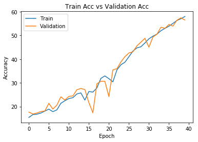

```python
pyplot.plot(trainAcc)
pyplot.plot(valAcc)
pyplot.title('Train Acc vs Validation Acc')
pyplot.xlabel('Epoch')
pyplot.ylabel('Accuracy')
pyplot.legend(['Train', 'Validation'], loc = 'upper left')
```

```python
trainLoss = trainProcess.history['loss']
valLoss = trainProcess.history['val_loss']
```

**Below plot shows the Train vs the validation loss during model training**

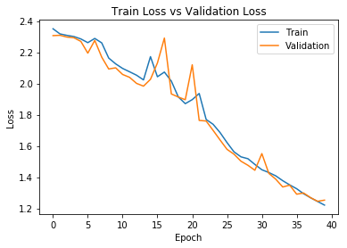

```python
pyplot.plot(trainLoss)
pyplot.plot(valLoss)
pyplot.title('Train Loss vs Validation Loss')
pyplot.xlabel('Epoch')
pyplot.ylabel('Loss')
pyplot.legend(['Train', 'Validation'], loc = 'upper right')
```

```python
model.save('Novel.h5')
```